### Beach dataset

The beach data set is made available from [here](https://github.com/rladiessydney/RYouWithMe) with minimal documentation. You need to make sure you have installed the package *readr*.

```r
library(readr)
library(tidyverse)
```

```r
library(ggplot2)
Syd_beach<-read_csv("https://raw.githubusercontent.com/rladiessydney/RYouWithMe/master/sydneybeaches.csv")
Syd_beach
```

```
## # A tibble: 3,690 x 8
##    BeachId Region    Council   Site   Longitude Latitude Date  `Enterococci (cf~
##      <dbl> <chr>     <chr>     <chr>      <dbl>    <dbl> <chr>             <dbl>
##  1      25 Sydney C~ Randwick~ Clove~      151.    -33.9 02/0~                19
##  2      25 Sydney C~ Randwick~ Clove~      151.    -33.9 06/0~                 3
##  3      25 Sydney C~ Randwick~ Clove~      151.    -33.9 12/0~                 2
##  4      25 Sydney C~ Randwick~ Clove~      151.    -33.9 18/0~                13
##  5      25 Sydney C~ Randwick~ Clove~      151.    -33.9 30/0~                 8
##  6      25 Sydney C~ Randwick~ Clove~      151.    -33.9 05/0~                 7
##  7      25 Sydney C~ Randwick~ Clove~      151.    -33.9 11/0~                11
##  8      25 Sydney C~ Randwick~ Clove~      151.    -33.9 23/0~                97
##  9      25 Sydney C~ Randwick~ Clove~      151.    -33.9 07/0~                 3
## 10      25 Sydney C~ Randwick~ Clove~      151.    -33.9 25/0~                 0
## # ... with 3,680 more rows
```

```r
str(Syd_beach)
```

```
## Classes 'spec_tbl_df', 'tbl_df', 'tbl' and 'data.frame': 3690 obs. of  8 variables:
##  $ BeachId                : num  25 25 25 25 25 25 25 25 25 25 ...
##  $ Region                 : chr  "Sydney City Ocean Beaches" "Sydney City Ocean Beaches" "Sydney City Ocean Beaches" "Sydney City Ocean Beaches" ...
##  $ Council                : chr  "Randwick Council" "Randwick Council" "Randwick Council" "Randwick Council" ...
##  $ Site                   : chr  "Clovelly Beach" "Clovelly Beach" "Clovelly Beach" "Clovelly Beach" ...
##  $ Longitude              : num  151 151 151 151 151 ...
##  $ Latitude               : num  -33.9 -33.9 -33.9 -33.9 -33.9 ...
##  $ Date                   : chr  "02/01/2013" "06/01/2013" "12/01/2013" "18/01/2013" ...
##  $ Enterococci (cfu/100ml): num  19 3 2 13 8 7 11 97 3 0 ...
##  - attr(*, "spec")=
##   .. cols(
##   ..   BeachId = col_double(),
##   ..   Region = col_character(),
##   ..   Council = col_character(),
##   ..   Site = col_character(),
##   ..   Longitude = col_double(),
##   ..   Latitude = col_double(),
##   ..   Date = col_character(),
##   ..   `Enterococci (cfu/100ml)` = col_double()
##   .. )
```

```r
Syd_beach$Site %>% unique
```

```
##  [1] "Clovelly Beach"          "Coogee Beach"
##  [3] "Gordons Bay (East)"      "Little Bay Beach"
##  [5] "Malabar Beach"           "Maroubra Beach"
##  [7] "South Maroubra Beach"    "South Maroubra Rockpool"
##  [9] "Bondi Beach"             "Bronte Beach"
## [11] "Tamarama Beach"
```

```r
Syd_beach$Region %>% unique
```

```
## [1] "Sydney City Ocean Beaches"
```

```r
Syd_beach$Council %>% unique
```

```
## [1] "Randwick Council" "Waverley Council"
```

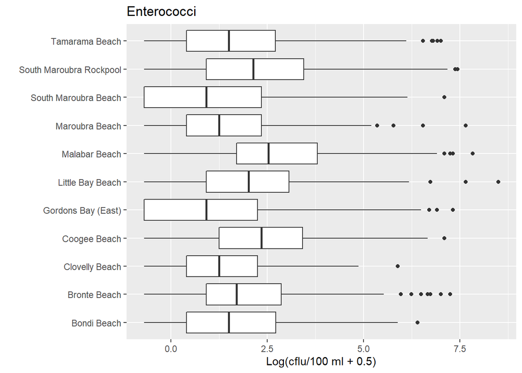

```r
p1<-qplot(Syd_beach$Site,log(Syd_beach$`Enterococci (cfu/100ml)`+0.5),data=Syd_beach,geom=c("boxplot"),main="Enterococci",xlab="",ylab="Log(cflu/100 ml + 0.5)")
p1+coord_flip()
```

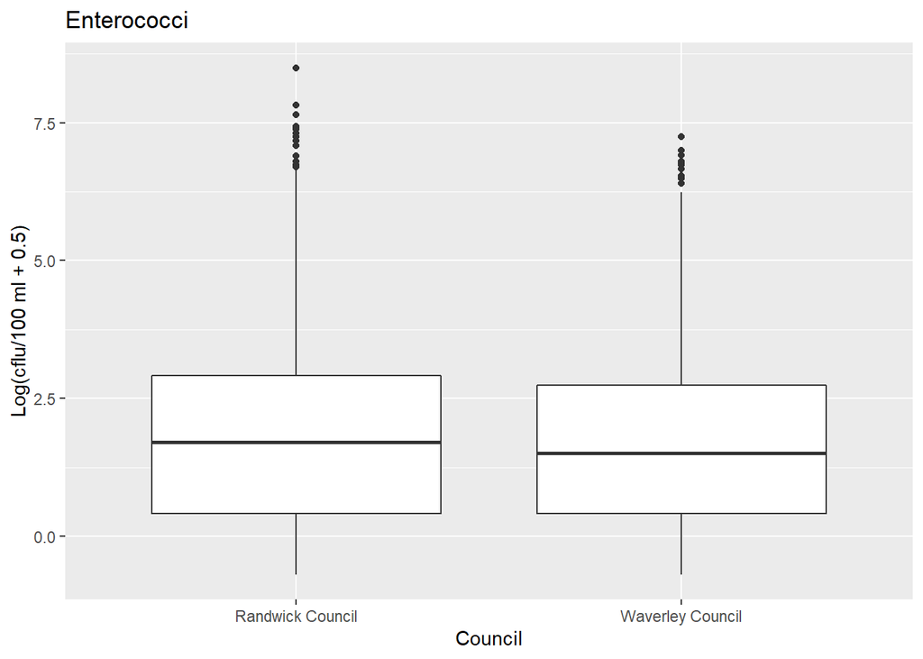

```r
qplot(Syd_beach$Council,log(Syd_beach$`Enterococci (cfu/100ml)`+0.5),data=Syd_beach,geom=c("boxplot"),main="Enterococci",xlab="Council",ylab="Log(cflu/100 ml + 0.5)")
```

### Environmental river flows

We are going to investigate the relationship between the Murray River average daily water level in metres (WaterLevel) and daily rainfall in mm at Pinegrove on the Murray River (Rainfall) available in the file *PineGrove19Aug19.csv*. It is reasonable to assume that the average daily water level is influenced by rainfall. This data covers the time period from 20 August 2018 to 19 August 2019. This data was extracted from [here](https://riverdata.mdba.gov.au/pinegrove) on 20 August 2019. Other locations could be extracted from [here](https://riverdata.mdba.gov.au/). Only the most recent year of data can be extracted.

```r
library(graphics)
Pinegrove<-read_csv("PineGrove19Aug19.csv")
Pinegrove
```

```
## # A tibble: 365 x 4
##    Date            WaterLevel Discharge Rainfall
##    <chr>                <dbl>     <dbl>    <dbl>
##  1 20/08/2018 9:00       1.56       897      1.2
##  2 21/08/2018 9:00       1.49       768      0.2
##  3 22/08/2018 9:00       1.48       753      0
##  4 23/08/2018 9:00       1.53       839      0
##  5 24/08/2018 9:00       1.48       758      0
##  6 25/08/2018 9:00       1.43       665      0
##  7 26/08/2018 9:00       1.40       625      4
##  8 27/08/2018 9:00       1.40       620      0
##  9 28/08/2018 9:00       1.38       596      0
## 10 29/08/2018 9:00       1.36       552      0
## # ... with 355 more rows
```

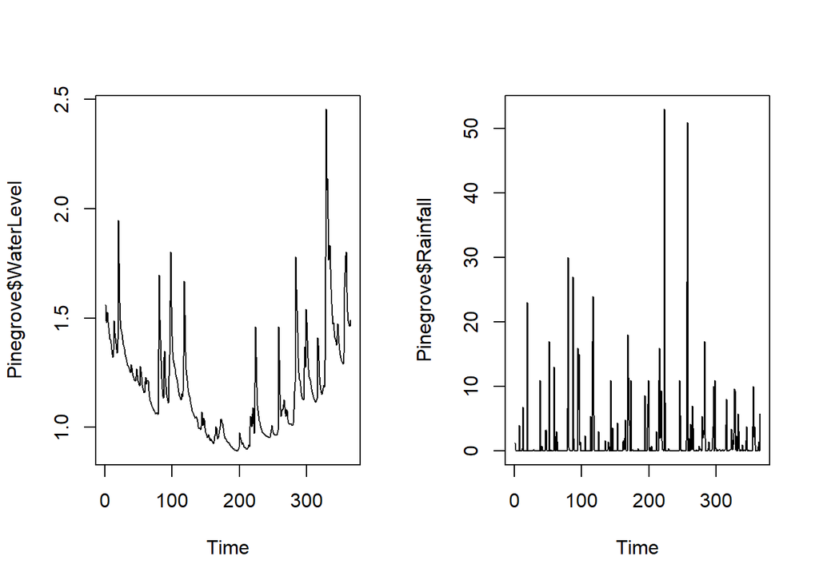

```r
par(mfrow=c(1,2))
plot.ts(Pinegrove$WaterLevel)
plot.ts(Pinegrove$Rainfall)
```

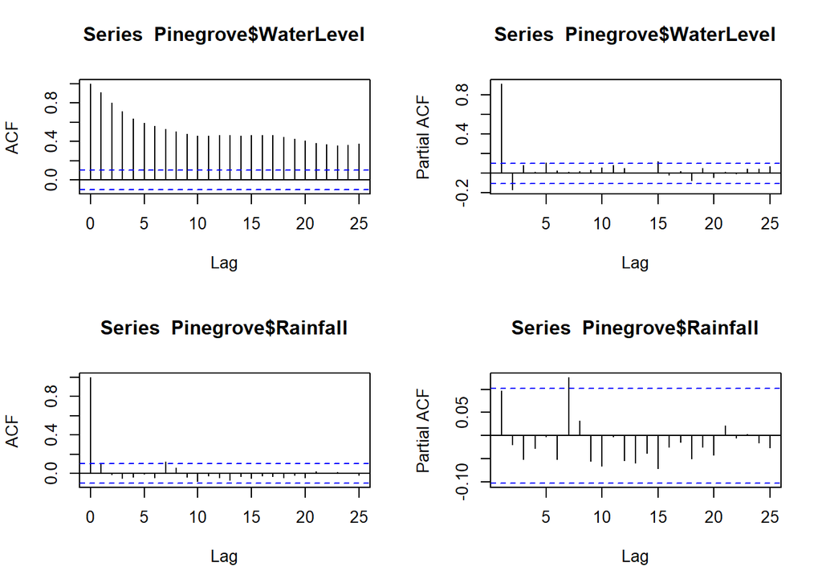

```r
require(graphics)
par(mfrow=c(2,2))
acf(Pinegrove$WaterLevel)
pacf(Pinegrove$WaterLevel)
acf(Pinegrove$Rainfall)
pacf(Pinegrove$Rainfall)
```

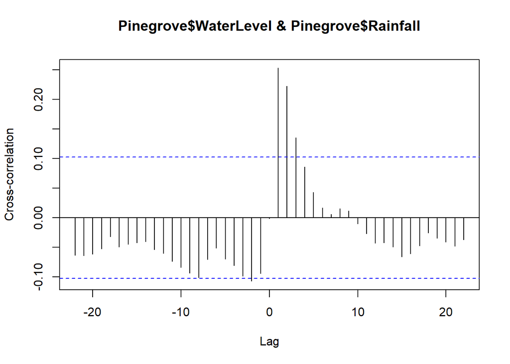

```r
par(mfrow=c(1,1))
 ccf(Pinegrove$WaterLevel, Pinegrove$Rainfall, ylab = "Cross-correlation")
```

### Birds datasets

Various datasets about Austrlian birds are [here](https://birdata.birdlife.org.au/).

### Atlas of living Australia

Search occurrence records in the ALA by species, taxon, dataset, region, date, location, data provider… Access the data [here](https://www.ala.org.au/).

### Bush Fires data

Download Near real-time MODIS (C6) and VIIRS (375 m) active fire data. Access the data [here](https://firms.modaps.eosdis.nasa.gov/active_fire/).

### Bureau of Meteorology data

The r package *bomrang* [here](https://cran.r-project.org/web/packages/bomrang/bomrang.pdf) has functions that extract Australian Government Bureau of Meteorology (‘BOM’) data.

### Queensland Government environmental maps and data online

Environment data is available from links on [here](https://environment.des.qld.gov.au/resources/maps-imagery-data/online).

### CSIRO Data Access Portal

Some of the data sets from [here](https://data.csiro.au/dap/browse) are not restricted access.

### Australian Ocean Data Network (AODN) Open Access to Ocean Data

Marine and climate science data can be accessed from [here](https://portal.aodn.org.au/).

### Australian fur seal (Brown fur seal) colonies in Victorian marine waters and adjacent Tasmanian waters

This can be ordered free from [here](https://discover.data.vic.gov.au/dataset/australian-fur-seal-brown-fur-seal-colonies-in-victorian-marine-waters-and-adjacent-tasmanian-w) which comes from *DataVic* which is the place to discover and access Victorian Government open data. See [here](https://data.vic.gov.au/) for access to other data sets.